# SL_A1_LDA

## MATH70097 - Supervised Learning: Assessment 1

A technology company is running an online advertising campaign. Users are shown a banner while browsing the web. Some users click on the banner and then subscribe to the service. This event is called a conversion. Your task is to predict whether a conversion occurs for each user, based on information about: • the user, • the current advertising campaign, • and a previous related advertising campaign. You will build a predictive model using historical data and use it to make predictions for new users.

Pulling from the lecture notes and assessment brief, we approach this assigment in 4 parts.

1. **Exploratory Data Analysis and Preprocessing** — understand the structure and signals, detect issues (missing values, unusual values, imbalance, nonlinearity).
2. **Building Prediction Models** — train and compare Logistic Regression (with Ridge and Lasso variants), kNN, LDA, QDA, and Naive Bayes.
3. **Validation and Model Selection** — 10-fold stratified CV for hyperparameter tuning, Bootstrap for uncertainty quantification, and principled model selection via log-loss.
4. **Generating Test Predictions** — refit on the full training set and produce predicted probabilities.

### Setup & Loading data

We import the relevant packages, set a seed, and load the data. The kernel used is the ISLP (Python 3.12.2) Kernel - which we setup in week 1 of the course.

```python
import numpy as np
import pandas as pd
import matplotlib.pyplot as plt
import seaborn as sns
from sklearn.model_selection import StratifiedKFold, cross_val_score, cross_val_predict
from sklearn.preprocessing import StandardScaler, OneHotEncoder
from sklearn.compose import ColumnTransformer
from sklearn.pipeline import Pipeline
from sklearn.linear_model import LogisticRegression
from sklearn.neighbors import KNeighborsClassifier
from sklearn.discriminant_analysis import LinearDiscriminantAnalysis, QuadraticDiscriminantAnalysis
from sklearn.naive_bayes import GaussianNB
from sklearn.metrics import log_loss, roc_auc_score, roc_curve, confusion_matrix
from sklearn.metrics import accuracy_score, precision_score, recall_score, f1_score
from sklearn.calibration import calibration_curve
from sklearn.decomposition import PCA
from sklearn.base import clone
import warnings
warnings.filterwarnings('ignore')

sns.set_theme(style='whitegrid', palette='muted')
pd.set_option('display.max_columns', 25)
SEED = 42
np.random.seed(SEED)
```

```python
train = pd.read_csv('train.csv')
test  = pd.read_csv('test.csv')
print(f"Training set : {train.shape[0]} rows, {train.shape[1]} columns")
print(f"Test set     : {test.shape[0]} rows, {test.shape[1]} columns")
train.head()
```

```
Training set : 31647 rows, 17 columns
Test set     : 13564 rows, 17 columns
```

|  | age | job | marital | education | X2 | X4 | X3 | X1 | device | day | month | time_spent | banner_views | days_elapsed_old | banner_views_old | outcome_old | y |
| --- | --- | --- | --- | --- | --- | --- | --- | --- | --- | --- | --- | --- | --- | --- | --- | --- | --- |
| 0 | 36 | technician | single | tertiary | 0 | 0 | 0 | 0 | unknown | 17 | jun | 153 | 4 | 368.0 | 0 | unknown | 0 |
| 1 | 56 | entrepreneur | married | secondary | 0 | 196 | 0 | 0 | cellular | 19 | nov | 312 | 3 | 348.0 | 0 | unknown | 0 |
| 2 | 46 | blue-collar | married | secondary | 0 | 0 | 1 | 0 | unknown | 5 | jun | 83 | 2 | 370.0 | 0 | unknown | 0 |
| 3 | 41 | management | divorced | tertiary | 0 | 3426 | 0 | 0 | cellular | 1 | oct | 302 | 1 | 119.0 | 5 | success | 0 |
| 4 | 38 | blue-collar | married | secondary | 0 | 0 | 1 | 0 | unknown | 20 | may | 90 | 1 | 351.0 | 0 | unknown | 0 |

### Part 1: Explore the training data (EDA)

Following the data descriptions from the brief, as well as looking through our dataframe, we choose to split the variables into two types. Quantitative variables and Qualitative (categorical) variables.

```python
# Define quantitative variables
quantitative = ['age', 'X4', 'day', 'time_spent', 'banner_views', 'days_elapsed_old', 'banner_views_old']

# Define qualitative variables
qualitative = ['job', 'marital', 'education', 'X1', 'X2', 'X3', 'device', 'outcome_old', 'month']

# Print qualitative and quantitative variables

print("Quantitative variables:")
print(train[quantitative].dtypes)
print("\nQualitative variables:")
for col in qualitative:
    levels = train[col].unique()
    print(f"{col} : {len(levels)} levels - {list(levels)}")

train.describe()
```

```
Quantitative variables:
age                   int64
X4                    int64
day                   int64
time_spent            int64
banner_views          int64
days_elapsed_old    float64
banner_views_old      int64
dtype: object

Qualitative variables:
job : 12 levels - ['technician', 'entrepreneur', 'blue-collar', 'management', 'admin.', 'retired', 'housemaid', 'unknown', 'services', 'student', 'unemployed', 'self-employed']
marital : 3 levels - ['single', 'married', 'divorced']
education : 4 levels - ['tertiary', 'secondary', 'primary', 'unknown']
X1 : 2 levels - [np.int64(0), np.int64(1)]
X2 : 2 levels - [np.int64(0), np.int64(1)]
X3 : 2 levels - [np.int64(0), np.int64(1)]
device : 3 levels - ['unknown', 'cellular', 'telephone']
outcome_old : 4 levels - ['unknown', 'success', 'other', 'failure']
month : 12 levels - ['jun', 'nov', 'oct', 'may', 'jul', 'aug', 'feb', 'dec', 'sep', 'jan', 'mar', 'apr']
```

|  | age | X2 | X4 | X3 | X1 | day | time_spent | banner_views | days_elapsed_old | banner_views_old | y |
| --- | --- | --- | --- | --- | --- | --- | --- | --- | --- | --- | --- |
| count | 31647.000000 | 31647.000000 | 31647.000000 | 31647.000000 | 31647.000000 | 31647.000000 | 31647.000000 | 31647.000000 | 31647.000000 | 31647.000000 | 31647.000000 |
| mean | 40.941669 | 0.019370 | 1357.985465 | 0.556040 | 0.160458 | 15.829621 | 257.570070 | 2.772237 | 354.627232 | 0.585869 | 0.430783 |
| std | 10.632010 | 0.137824 | 2976.874443 | 0.496857 | 0.367036 | 8.323200 | 258.833768 | 3.154004 | 104.887762 | 2.435961 | 0.495194 |
| min | 18.000000 | 0.000000 | -6847.000000 | 0.000000 | 0.000000 | 1.000000 | 0.000000 | 1.000000 | 1.000000 | 0.000000 | 0.000000 |
| 25% | 33.000000 | 0.000000 | 70.000000 | 0.000000 | 0.000000 | 8.000000 | 103.000000 | 1.000000 | 347.000000 | 0.000000 | 0.000000 |
| 50% | 39.000000 | 0.000000 | 446.000000 | 1.000000 | 0.000000 | 16.000000 | 180.000000 | 2.000000 | 358.000000 | 0.000000 | 0.000000 |
| 75% | 48.000000 | 0.000000 | 1434.000000 | 1.000000 | 0.000000 | 21.000000 | 319.000000 | 3.000000 | 369.000000 | 0.000000 | 1.000000 |
| max | 95.000000 | 1.000000 | 81204.000000 | 1.000000 | 1.000000 | 31.000000 | 4918.000000 | 63.000000 | 871.000000 | 275.000000 | 1.000000 |

We find that there are no null or NaN values in the dataset. However, for 'job', 'education', 'device' and 'outcome_old', we have "unknown" values to serve as a missing indicator.

```python
print("NaN/Null values in training set:")
print(train.isnull().sum())
```

```
NaN/Null values in training set:
age                 0
job                 0
marital             0
education           0
X2                  0
X4                  0
X3                  0
X1                  0
device              0
day                 0
month               0
time_spent          0
banner_views        0
days_elapsed_old    0
banner_views_old    0
outcome_old         0
y                   0
dtype: int64
```

```python
print("unknown values in training set:")
for x in ['job', 'education', 'device', 'outcome_old']:
    unknown_count = (train[x] == 'unknown').sum()
    percentage = (unknown_count / len(train)) * 100
    print(f"{x} : {unknown_count} ({percentage:.2f}%)")
```

```
unknown values in training set:
job : 203 (0.64%)
education : 1322 (4.18%)
device : 9065 (28.64%)
outcome_old : 25867 (81.74%)
```

```python
print("No. of days_elapsed_old = -1 in training set:")
print((train['days_elapsed_old'] == -1).sum())

print("No.of days_elapsed_old = -1 in test set:")
print((test['days_elapsed_old'] == -1).sum())
```

```
No. of days_elapsed_old = -1 in training set:
0
No.of days_elapsed_old = -1 in test set:
0
```

##### Missing values takeaway

"unknown": we can retain "unknown" as a factor level. The lack of a value itself provides us with information on users which were not exposed to the old banner

'days_elapsed_old': No -1 values are found in our dataset, so we can avoid handling this case specifically as we don't have any test or train data for it.

Numeric Variables: There are no missing numerical values, so we do not have to perform specific imputation (filling).

After checking for missing and unusual values, we check for imbalances.

```
Overall conversion rate (y=1) in training set: 0.4308
Class imbalance ratio (y=0 : y=1) in training set: 1.32 : 1
```

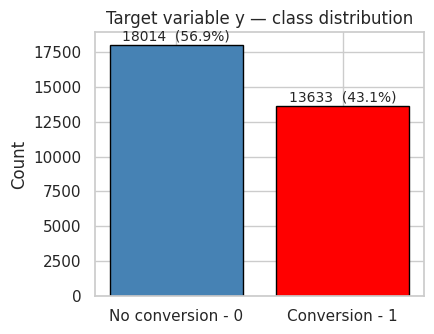

```python
rate = train['y'].mean()
print(f"Overall conversion rate (y=1) in training set: {rate:.4f}")
ratio = (train['y'] == 0).sum() / (train['y'] == 1).sum()
print(f"Class imbalance ratio (y=0 : y=1) in training set: {ratio:.2f} : 1")

fig, ax = plt.subplots(figsize=(4.5, 3.5))
counts = train['y'].value_counts().sort_index()
bars = ax.bar(['No conversion - 0', 'Conversion - 1'], counts.values,
              color=['steelblue', 'red'], edgecolor='black')
for i, v in enumerate(counts.values):
    ax.text(i, v + 300, f"{v}  ({100*v/len(train):.1f}%)", ha='center', fontsize=10)
ax.set_ylabel('Count')
ax.set_title('Target variable y — class distribution')
plt.tight_layout()
plt.show()
```

##### Imbalances takeaway

The targeted split has a mild imbalance, 57% non-conversion to 43% conversion. We shouldn't use specific resampling techniques here, but we do focus on a couple of key points:

1. Use stratified cross-validation to preserve class proportions in every fold.
2. Keep the baseline in mind: a naïve classifier predicting the majority class achieves only ~57% accuracy.

We proceed to visualise structure:

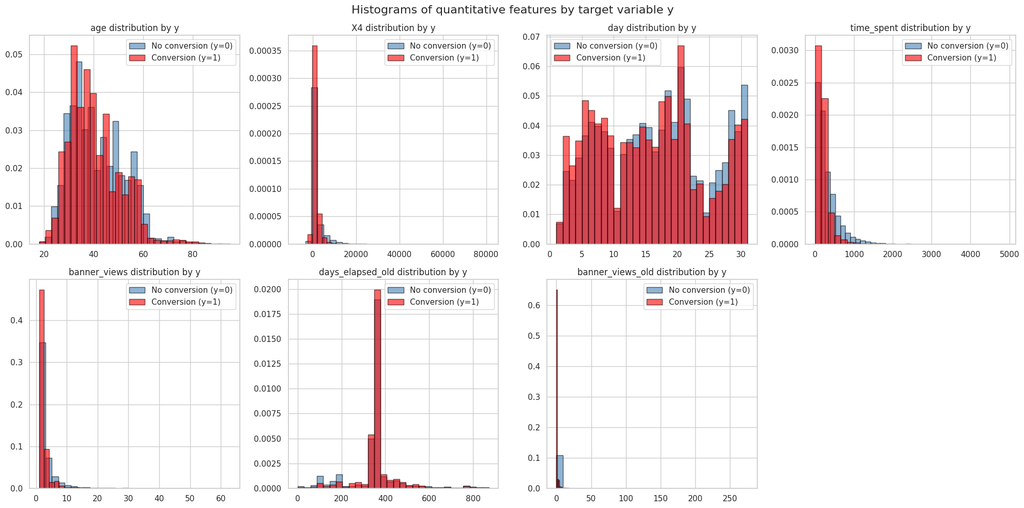

```python
fig, axes = plt.subplots(2, 4, figsize=(20, 10))
axes = axes.ravel()

for i, col in enumerate(quantitative):
    ax = axes[i]
    for yval, colour, label in [(0, 'steelblue', 'No conversion (y=0)'),
                             (1, 'red', 'Conversion (y=1)')]:
        subset = train.loc[train['y'] == yval, col]
        ax.hist(subset, bins=30, alpha=0.6, color=colour, label=label, edgecolor='black', density=True)
    ax.set_title(f"{col} distribution by y")
    ax.legend()

axes[-1].set_visible(False)
plt.suptitle("Histograms of quantitative features by target variable y", fontsize=16)
plt.tight_layout()
plt.show()
```

##### Quantitative structure takeaways

We find a couple of key observations that may help us out:

X4 is heavily right-skewed, so a log-transform may help with our linear-models.

banner_views and banner_views_old are right-skewed.

time_spent interestingly shows a significant shift between classes. Non-conversion (y=0) spend more time. This seems to signal that quick engagement and attention-capture has a larger chance of conversion.

age is (rougly) symmetric, and has some class seperation.

We move onto exploring quantitative variables

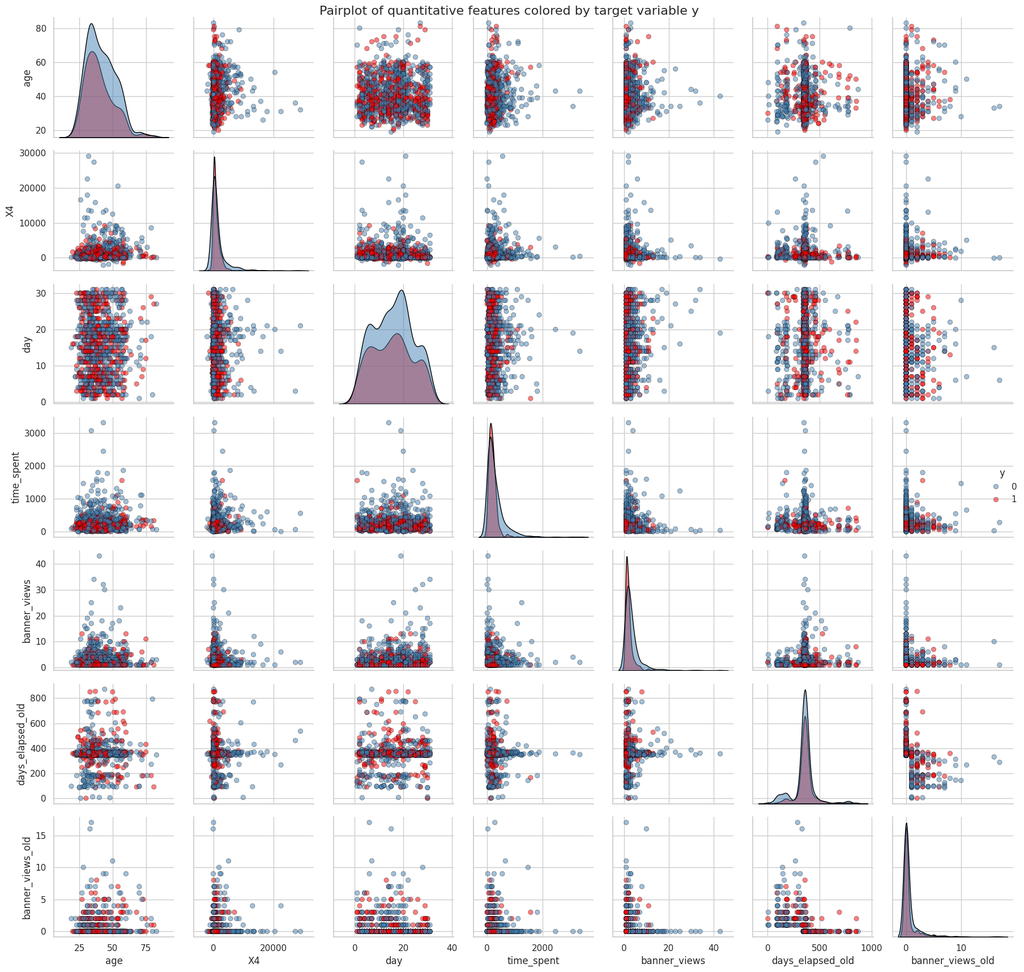

```python
vars = quantitative
sample = train[vars + ['y']].sample(1000, random_state=SEED)
sample['y'] = sample['y'].astype(str)

g = sns.pairplot(sample, hue='y', vars=vars, diag_kind='kde',
                 palette={'0': 'steelblue', '1': 'red'},
                 plot_kws={'alpha': 0.5, 'edgecolor': 'black'},
                 diag_kws={'alpha': 0.5, 'edgecolor': 'black'})
g.fig.suptitle("Pairplot of quantitative features colored by target variable y", fontsize=16)
plt.tight_layout()
plt.show()
```

Our pairplot reveals substantial overlaps. No single feature seperates conversion rate cleanly.

We move onto conversion rate by categorical variables

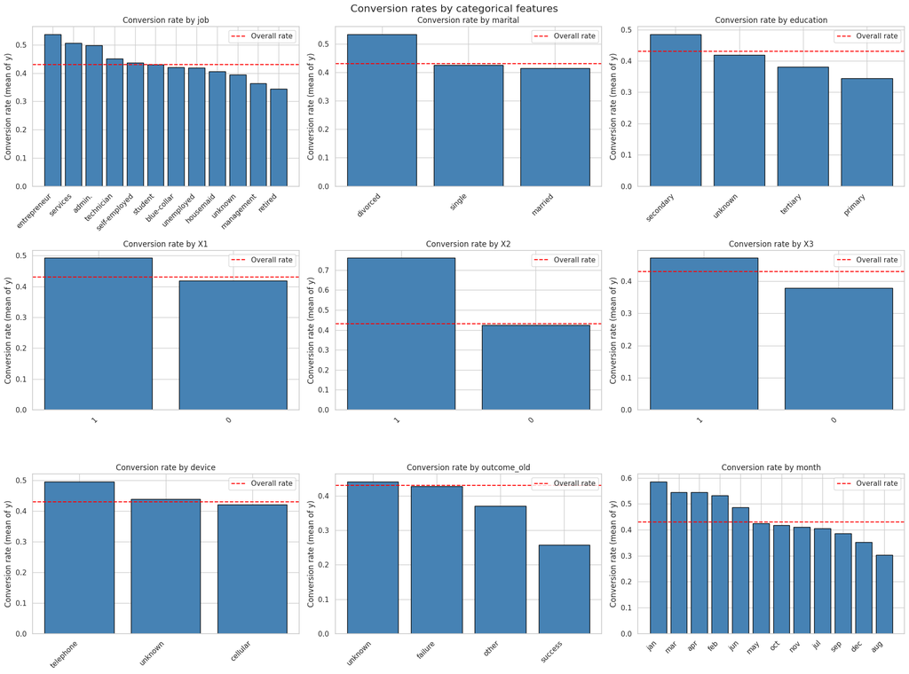

```python
cat_vars = qualitative
fig, axes = plt.subplots(3, 3, figsize=(20, 15))
for ax, col in zip(axes.ravel(), cat_vars):
    rates = train.groupby(col)['y'].agg(['mean', 'count']).sort_values('mean', ascending=False)
    bars = ax.bar(range(len(rates)), rates['mean'], color='steelblue', edgecolor='black')
    ax.set_xticks(range(len(rates)))
    ax.set_xticklabels(rates.index, rotation=45, ha='right')
    ax.set_title(f"Conversion rate by {col}")
    ax.set_ylabel("Conversion rate (mean of y)")
    ax.axhline(train['y'].mean(), color='red', linestyle='--', label='Overall rate')
    ax.legend()
plt.suptitle("Conversion rates by categorical features", fontsize=16)
plt.tight_layout()
plt.show()
```

##### Key Qualitative (categorical) takeaways:

outcome_old: "success" has the lowest conversion rate, around 26%.

month: suggests seasonal variation, with Jan, Mar, April being the highest.

We proceed to check for correlation structure and nonlinerarity

```python
# Pearson correlation of quantitative features with target variable y
corr = train[quantitative + ['y']].corr().drop('y').sort_values('y', ascending=True)
print("Pearson correlation of target variable y:")
for var, val in corr['y'].items():
    bar = '█' * int(abs(val) * 50)
    sign = '+' if val > 0 else '-'
    print(f"{var:20s} : {val:.4f} {sign} {bar}")
```

```
Pearson correlation of target variable y:
time_spent           : -0.2009 - ██████████
banner_views         : -0.1687 - ████████
X4                   : -0.0778 - ███
day                  : -0.0639 - ███
age                  : -0.0531 - ██
banner_views_old     : -0.0224 - █
days_elapsed_old     : 0.0542 + ██
```

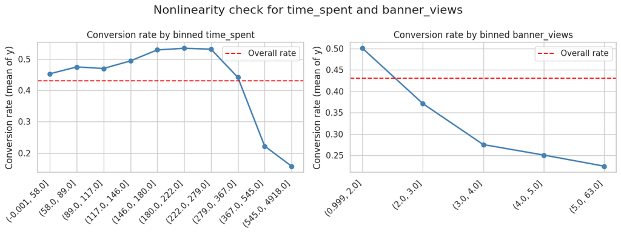

```python
# Nonlinearity check

fig, axes = plt.subplots(1, 2, figsize=(12, 4.5))

for ax, col in zip(axes, ['time_spent', 'banner_views']):
    helper = train.copy()
    helper[col + '_bin'] = pd.qcut(helper[col], q=10, duplicates='drop')
    rates = helper.groupby(col + '_bin')['y'].mean()
    ax.plot(range(len(rates)), rates.values, 'o-', color='steelblue', linewidth=2)
    ax.set_xticks(range(len(rates)))
    ax.set_xticklabels(rates.index.astype(str), rotation=45, ha='right')
    ax.set_title(f"Conversion rate by binned {col}")
    ax.set_ylabel("Conversion rate (mean of y)")
    ax.axhline(train['y'].mean(), color='red', linestyle='--', label='Overall rate')
    ax.legend()
plt.suptitle("Nonlinearity check for time_spent and banner_views", fontsize=16)
plt.tight_layout()
plt.show()
```

Dimensionality discussion

The curse of dimensionality is an important theoretical consideration. The number of predictors p is large relative to the structure of the data, expanding our dimensionality.

```python
# Dimensionality count after one-hot encoding
var_counts = ['job', 'marital', 'education', 'device', 'outcome_old', 'month']
levels = sum(train[var].nunique() for var in var_counts)

dummies = sum(train[var].nunique() - 1 for var in var_counts)

n_numeric = len(quantitative)
n_binary = 3
n_engineered = 4

p_total = n_numeric + dummies + n_binary + n_engineered
n = len(train)

print(f"Total features after one-hot encoding: {p_total}")
print(f"Number of training samples: {n}")
print(f"n/p ratio: {n/p_total:.0f}")
```

```
Total features after one-hot encoding: 46
Number of training samples: 31647
n/p ratio: 688
```

The n/p ratio is comfortable for parametric models at 688, but the expanded dimensionality has consequences for kNN:

The nearest neighbour degrades. As data points become approximately equidistant, the query point no longer remains local.This leads to kNN bias increasing in average dimensions, as it averages over points that are not close, and so can no longer effectively capture local structure. This leads to a large k to stabilise predictions. We may find that Lasso logistic regression or Naive bayes work better here.

Feature encoding takeways

We define the processing pipeline across all models tested, as such:

Quantitative variables - standardised using StandardScalar for kNN and regularised logistical regression.

We proceed with feature engineering:

```python
def engineer_features(df):
    df = df.copy()
    df['old_campaign_exposed'] = (df['banner_views_old'] > 0).astype(int)
    df['old_success'] = (df['outcome_old'] == 'success').astype(int)
    df['time_per_view'] = df['time_spent'] / (df['banner_views'] + 1).clip(lower=1)  # Avoid division by zero
    df['X4_log'] = np.sign(df['X4']) * np.log1p(np.abs(df['X4']))  # Log-transform X4 while preserving sign
    return df

train_featured = engineer_features(train)
test_featured = engineer_features(test)

print("New features added: old_campaign_exposed, old_success, time_per_view, X4_log")
```

```
New features added: old_campaign_exposed, old_success, time_per_view, X4_log
```

```python
numeric_features = quantitative + ['time_per_view', 'X4_log']
binary_features = ['old_campaign_exposed', 'old_success', 'X1', 'X2', 'X3']
categorical_features = ['job', 'marital', 'education', 'device', 'outcome_old', 'month']

all_features = numeric_features + binary_features + categorical_features
print(f"Total features after engineering: {len(all_features)}")

x_train = train_featured[all_features]
y_train = train_featured['y']
x_test = test_featured[all_features]
test_ids = test_featured['ID']

# Preprocessor pipeline
preprocessor = ColumnTransformer(
    transformers=[
        ('num', StandardScaler(), numeric_features),
        ('bin', 'passthrough', binary_features),
        ('cat', OneHotEncoder(handle_unknown='ignore', sparse_output=False), categorical_features),
    ]
)

print("Preprocessor pipeline created with standard scaling for numeric features, passthrough for binary features, and one-hot encoding for categorical features.")
print(f"feature breakdown: {len(numeric_features)} numeric, {len(binary_features)} binary, {len(categorical_features)} categorical (one-hot encoded to {dummies} features)")
print(f"X_train shape before preprocessing: {x_train.shape}, X_test shape before preprocessing: {x_test.shape}")
```

```
Total features after engineering: 20
Preprocessor pipeline created with standard scaling for numeric features, passthrough for binary features, and one-hot encoding for categorical features.
feature breakdown: 9 numeric, 5 binary, 6 categorical (one-hot encoded to 32 features)
X_train shape before preprocessing: (31647, 20), X_test shape before preprocessing: (13564, 20)
```

PCA Analysis

PCA Analysis was introduced in week 4 as an unsupervised tool to find maximal variance directions. We apply it to check if the data admits a low-dimensional structure, and visualises class seperation in the reduced spaces.

```
X_train shape after preprocessing: (31647, 52)
Shape of PCA-transformed training data: (31647, 10)
```

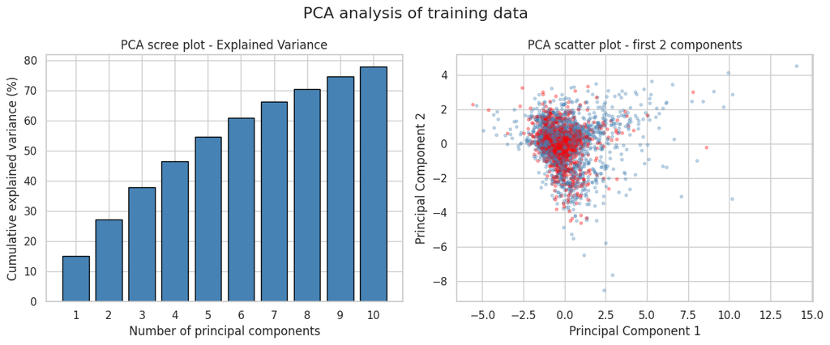

```
Cumulative variance explained by 5 PCs: 54.5%
Cumulative variance explained by 10 PCs: 77.8%
```

```python
X_train_processed = preprocessor.fit_transform(x_train)
print(f"X_train shape after preprocessing: {X_train_processed.shape}")

pca = PCA(n_components=10, random_state=SEED)
X_pca = pca.fit_transform(X_train_processed)
print(f"Shape of PCA-transformed training data: {X_pca.shape}")

fig, axes = plt.subplots(1, 2, figsize=(12, 5))

ax = axes[0]
cum_var = np.cumsum(pca.explained_variance_ratio_) * 100
ax.bar = ax.bar(range(1, len(cum_var) + 1), cum_var, color='steelblue', edgecolor='black')
ax.set_xticks(range(1, len(cum_var) + 1))
ax.set_xticklabels(range(1, len(cum_var) + 1))
ax.set_xlabel('Number of principal components')
ax.set_ylabel('Cumulative explained variance (%)')
ax.set_title('PCA scree plot - Explained Variance')

ax = axes[1]
colours = y_train.map({0: 'steelblue', 1: 'red'})
sample_idx = np.random.choice(len(X_pca), size=3000, replace=False)
ax.scatter(X_pca[sample_idx, 0], X_pca[sample_idx, 1], c=colours.iloc[sample_idx], alpha=0.3, s=8)
ax.set_xlabel('Principal Component 1')
ax.set_ylabel('Principal Component 2')
ax.set_title('PCA scatter plot - first 2 components')

plt.suptitle("PCA analysis of training data", fontsize=16)
plt.tight_layout()
plt.show()

print(f"Cumulative variance explained by 5 PCs: {cum_var[4]:.1f}%")
print(f"Cumulative variance explained by 10 PCs: {cum_var[9]:.1f}%")
```

The PCA Scree plot confirms the high-effective dimensionality, there is no clear seperator in low dimensional projections.

#### EDA Recap

Moderate class imbalance (43% positive): Use stratified CV; log-loss as evaluation metric.

"unknown" encodes structural missingness: Retain as its own category, do not impute.

No literal NaN in numeric columns: No numeric imputation needed.

outcome_old = "success" has the lowest conversion: Strong predictor; include as feature.

X4 heavily skewed: Apply log-transform.

### Step 2 - Model Building and Justification

We choose to train 6 models, covered by the course. We see no reason to combine models, as EDA does not strongly suggest a benefit. All models are wrapped in a pipeline with consistent preprocessing. Models are listed as follows:

1. Logistic regression (Ride/L2) - directly estimates P(y=1|X) with L2 regularisation.
2. Logistic regression (Lasso/L1) - same as above but with an L1 penalty, performing automatic variable selection by shrinking irrelevant coeefficients to 0. Useful due to unnamed and dummy variables.
3. k-nearest neighbours - non-parametric, requires standardised features.
4. Linear Discriminant Analysis - assumes each class has a multivariate guassian distribution with a shared covariance matrix.
5. Quadratic Discriminant Analysis - similar to LDA, but allows each class to have its own covariance matrix, leading to flexibility at the cost of more estimate parameters.
6. Naive Bayes - assumes predictors are independent given the class. This "naive" assumption effectively reduces a p-dimensional estimation problem to *p* univariate problems, dramatically reducing variance. This makes it well-suited to the high dimensionality after one-hot encoding, at the cost of potentially increased bias if predictors are correlated.

```python
cv = StratifiedKFold(n_splits=10, shuffle=True, random_state=SEED)

models = {
    'Logistic Regression (Ridge, C=1)': Pipeline([
        ('pre', preprocessor),
        ('clf', LogisticRegression(penalty='l2', C=1.0, max_iter=2000,
                                    solver='lbfgs', random_state=SEED))
    ]),
    'Logistic Regression (Lasso, C=1)': Pipeline([
        ('pre', preprocessor),
        ('clf', LogisticRegression(penalty='l1', C=1.0, max_iter=2000,
                                    solver='saga', random_state=SEED))
    ]),
    'kNN (k=30)': Pipeline([
        ('pre', preprocessor),
        ('clf', KNeighborsClassifier(n_neighbors=30))
    ]),
    'LDA': Pipeline([
        ('pre', preprocessor),
        ('clf', LinearDiscriminantAnalysis())
    ]),
    'QDA': Pipeline([
        ('pre', preprocessor),
        ('clf', QuadraticDiscriminantAnalysis(reg_param=0.5))
    ]),
    'Naive Bayes': Pipeline([
        ('pre', preprocessor),
        ('clf', GaussianNB())
    ]),
}

print(f"{'Model':<40s}  {'Log-Loss':>18s}  {'ROC-AUC':>18s}")
print('-' * 80)

results = {}
for name, pipe in models.items():
    ll_scores  = cross_val_score(pipe, x_train, y_train, cv=cv,
                                  scoring='neg_log_loss', n_jobs=-1)
    auc_scores = cross_val_score(pipe, x_train, y_train, cv=cv,
                                  scoring='roc_auc', n_jobs=-1)
    results[name] = {
        'log_loss_mean': -ll_scores.mean(),
        'log_loss_std':   ll_scores.std(),
        'auc_mean':       auc_scores.mean(),
        'auc_std':        auc_scores.std(),
    }
    print(f"{name:<40s}  {-ll_scores.mean():.4f} ± {ll_scores.std():.4f}   "
          f"{auc_scores.mean():.4f} ± {auc_scores.std():.4f}")
```

```
Model                                               Log-Loss             ROC-AUC
--------------------------------------------------------------------------------
Logistic Regression (Ridge, C=1)          0.5834 ± 0.0085   0.7597 ± 0.0100
Logistic Regression (Lasso, C=1)          0.5833 ± 0.0085   0.7598 ± 0.0100
kNN (k=30)                                0.5281 ± 0.0123   0.8174 ± 0.0101
LDA                                       0.5872 ± 0.0071   0.7524 ± 0.0102
QDA                                       0.6983 ± 0.0334   0.7682 ± 0.0108
Naive Bayes                               1.8148 ± 0.1212   0.7059 ± 0.0115
```

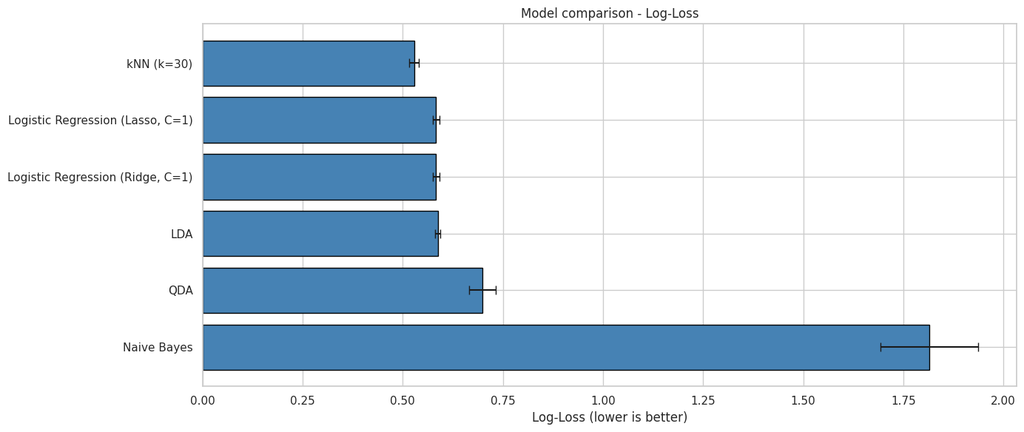

```python
res_df = pd.DataFrame(results).T.sort_values('log_loss_mean')

fig, ax = plt.subplots(figsize=(14, 6))
ax.barh(res_df.index, res_df['log_loss_mean'], xerr=res_df['log_loss_std'],
        color='steelblue', edgecolor='black', capsize=4)
ax.set_xlabel('Log-Loss (lower is better)')
ax.set_title('Model comparison - Log-Loss')
ax.invert_yaxis()
plt.tight_layout()
plt.show()
```

#### Initial comparison takeaways:

1. Ridge and Lasso Logistic regression perform similarly at C = 1. We will tune for C for each seperately.
2. LDA compares to logistic regression, as expected as we estimate similar linear boundaries.
3. Naive Bayes has a significant log-loss, indicating that bias may be introduced as predictors are correlated (time_spent, banner views)
4. QDA seems to struggle with high-dimensional one-hot encoded features
5. KNN has not been tuned yet - its performance depends on k.

### Step 3 - Validation and model selection

We use a 10-fold stratified cross-validation to tune hyperparameters, with the primary metric being log-loss to select models. We also use Bootstrao to quantify uncertainty for our performance metrics and assess whether differences are statistically meaningful.

Logistic Regression - Ridge tuning:

```python
C_values = [0.001, 0.01, 0.05, 0.1, 0.5, 1.0, 5.0, 10.0, 50.0, 100.0]
ridge_results = []

for C in C_values:
    pipe = Pipeline([
        ('pre', preprocessor),
        ('clf', LogisticRegression(penalty='l2', C=C, max_iter=2000,
                                    solver='lbfgs', random_state=SEED))
    ])
    scores = cross_val_score(pipe, x_train, y_train, cv=cv,
                                scoring='neg_log_loss', n_jobs=-1)
    ridge_results.append({
        'C': C,
        'log_loss_mean': -scores.mean(),
        'log_loss_std': scores.std()
    })
    print(f"Ridge Logistic Regression (C={C}) - log-loss: {-scores.mean():.4f} ± {scores.std():.4f}")

ridge_df = pd.DataFrame(ridge_results)
best_C_ridge = ridge_df.loc[ridge_df['log_loss_mean'].idxmin(), 'C']
best_ll_ridge = ridge_df['log_loss_mean'].min()
print(f"\nBest Ridge Logistic Regression - C={best_C_ridge}, log-loss = {best_ll_ridge:.4f}")
```

```
Ridge Logistic Regression (C=0.001) - log-loss: 0.6036 ± 0.0061
Ridge Logistic Regression (C=0.01) - log-loss: 0.5863 ± 0.0081
Ridge Logistic Regression (C=0.05) - log-loss: 0.5836 ± 0.0084
Ridge Logistic Regression (C=0.1) - log-loss: 0.5834 ± 0.0085
Ridge Logistic Regression (C=0.5) - log-loss: 0.5834 ± 0.0085
Ridge Logistic Regression (C=1.0) - log-loss: 0.5834 ± 0.0085
Ridge Logistic Regression (C=5.0) - log-loss: 0.5834 ± 0.0085
Ridge Logistic Regression (C=10.0) - log-loss: 0.5834 ± 0.0085
Ridge Logistic Regression (C=50.0) - log-loss: 0.5834 ± 0.0085
Ridge Logistic Regression (C=100.0) - log-loss: 0.5834 ± 0.0085

Best Ridge Logistic Regression - C=0.5, log-loss = 0.5834
```

Logistic Regression - Lasso Tuning:

```python
lasso_results = []

for C in C_values:
    pipe = Pipeline([
        ('pre', preprocessor),
        ('clf', LogisticRegression(penalty='l1', C=C, max_iter=2000,
                                    solver='saga', random_state=SEED))
    ])
    scores = cross_val_score(pipe, x_train, y_train, cv=cv, scoring='neg_log_loss', n_jobs=-1)
    lasso_results.append({
        'C': C,
        'log_loss_mean': -scores.mean(),
        'log_loss_std': scores.std()
    })
    print(f"Lasso Logistic Regression (C={C}) - log-loss: {-scores.mean():.4f} ± {scores.std():.4f}")

lasso_df = pd.DataFrame(lasso_results)
best_C_lasso = lasso_df.loc[lasso_df['log_loss_mean'].idxmin(), 'C']
best_ll_lasso = lasso_df['log_loss_mean'].min()
print(f"\nBest Lasso Logistic Regression - C={best_C_lasso}, log-loss = {best_ll_lasso:.4f}")
```

```
Lasso Logistic Regression (C=0.001) - log-loss: 0.6456 ± 0.0033
Lasso Logistic Regression (C=0.01) - log-loss: 0.5939 ± 0.0077
Lasso Logistic Regression (C=0.05) - log-loss: 0.5839 ± 0.0085
Lasso Logistic Regression (C=0.1) - log-loss: 0.5834 ± 0.0085
Lasso Logistic Regression (C=0.5) - log-loss: 0.5833 ± 0.0085
Lasso Logistic Regression (C=1.0) - log-loss: 0.5833 ± 0.0085
Lasso Logistic Regression (C=5.0) - log-loss: 0.5834 ± 0.0085
Lasso Logistic Regression (C=10.0) - log-loss: 0.5834 ± 0.0085
Lasso Logistic Regression (C=50.0) - log-loss: 0.5834 ± 0.0085
Lasso Logistic Regression (C=100.0) - log-loss: 0.5834 ± 0.0085

Best Lasso Logistic Regression - C=0.5, log-loss = 0.5833
```

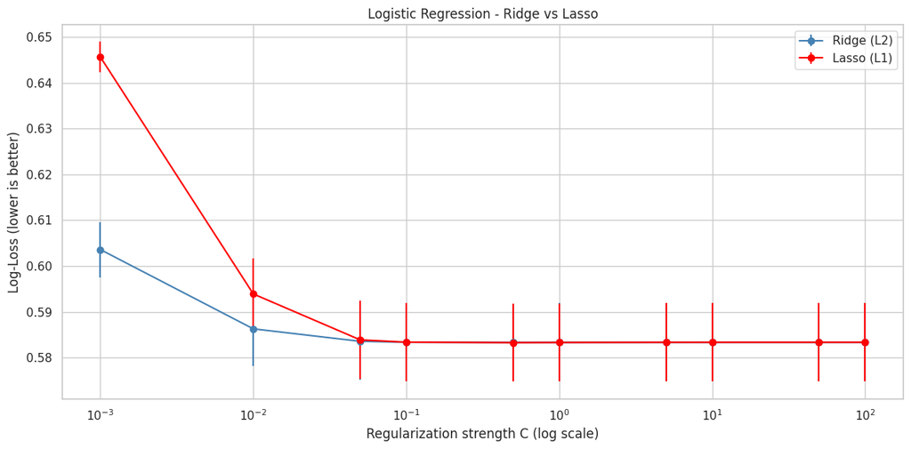

```python
# Compare Ridge and Lasso results

fig, ax = plt.subplots(figsize=(12, 6))
ax.errorbar(ridge_df['C'], ridge_df['log_loss_mean'], yerr=ridge_df['log_loss_std'], fmt='o-', label='Ridge (L2)', color='steelblue')
ax.errorbar(lasso_df['C'], lasso_df['log_loss_mean'], yerr=lasso_df['log_loss_std'], fmt='o-', label='Lasso (L1)', color='red')
ax.set_xscale('log')
ax.set_xlabel('Regularization strength C (log scale)')
ax.set_ylabel('Log-Loss (lower is better)')
ax.set_title('Logistic Regression - Ridge vs Lasso')
ax.legend()
plt.tight_layout()
plt.show()
```

Model does not seem overtly sensitive to regularisation. If the best log-loss results are similar, Lasso is preferred for its variable selection properties, leading to a more interpretable model.

We continue to check which cofefficients shrunk to 0 for the best C for the Lasso model.

```python
# Fit lasso on best C on full training data
lasso_inspect = Pipeline([
    ('pre', preprocessor),
    ('clf', LogisticRegression(penalty='l1', C=best_C_lasso, max_iter=2000,
                                solver='saga', random_state=SEED))
])
lasso_inspect.fit(x_train, y_train)

# Get feature names after preprocessing
ohe = lasso_inspect.named_steps['pre'].named_transformers_['cat']
cat_feature_names = ohe.get_feature_names_out(categorical_features).tolist()
feature_names = numeric_features + binary_features + cat_feature_names

lasso_coefs = pd.Series(lasso_inspect.named_steps['clf'].coef_[0], index=feature_names)
n_zero = (lasso_coefs == 0).sum()
n_nonzero = (lasso_coefs != 0).sum()

print(f"Total features after preprocessing: {len(feature_names)}")
print(f"Number of features with zero coefficients: {n_zero}")
print(f"Number of features with non-zero coefficients: {n_nonzero}")
print(("Features removed by Lasso (zero coefficients):\n")
      + "\n".join(lasso_coefs[lasso_coefs == 0].index.tolist()))

print("Survival of features with non-zero coefficients in Lasso:")
surviving_features = lasso_coefs[lasso_coefs != 0].reindex(
    lasso_coefs[lasso_coefs != 0].abs().sort_values(ascending=False).index)
for feat, coef in surviving_features.items():
    print(f"{feat:40s} : {coef:.4f}")
```

```
Total features after preprocessing: 52
Number of features with zero coefficients: 3
Number of features with non-zero coefficients: 49
Features removed by Lasso (zero coefficients):
job_technician
job_unknown
month_oct
Survival of features with non-zero coefficients in Lasso:
X2                                       : 2.2372
time_spent                               : -0.9016
banner_views                             : -0.5902
month_mar                                : 0.5135
month_jan                                : 0.5109
month_aug                                : -0.5068
X3                                       : 0.4761
month_nov                                : -0.4630
X4_log                                   : 0.4339
device_telephone                         : 0.4264
job_entrepreneur                         : 0.4245
device_unknown                           : -0.4130
X4                                       : -0.4089
education_primary                        : -0.3984
old_campaign_exposed                     : -0.3894
marital_divorced                         : 0.3762
month_may                                : -0.3602
month_jul                                : -0.3426
marital_single                           : -0.2997
X1                                       : 0.2773
month_apr                                : 0.2668
job_management                           : -0.2541
month_jun                                : 0.2395
job_retired                              : -0.2221
old_success                              : -0.2107
outcome_old_success                      : -0.2107
time_per_view                            : 0.2081
education_secondary                      : 0.2079
marital_married                          : -0.1905
outcome_old_other                        : -0.1537
month_feb                                : 0.1453
job_student                              : -0.1413
outcome_old_unknown                      : 0.1353
job_unemployed                           : -0.1329
device_cellular                          : -0.1273
job_services                             : 0.1235
age                                      : -0.1093
job_blue-collar                          : -0.0859
day                                      : -0.0763
education_tertiary                       : -0.0714
days_elapsed_old                         : 0.0694
education_unknown                        : 0.0417
month_dec                                : -0.0399
outcome_old_failure                      : 0.0231
banner_views_old                         : 0.0213
month_sep                                : -0.0189
job_self-employed                        : 0.0148
job_admin.                               : 0.0136
job_housemaid                            : 0.0093
```

Tuning kNN

The choice of k directly controls the bias-variance trade-off:

- Small k leads to low bias, high variance (overfitting risk).
- Large k leads to high bias, low variance (underfitting risk).

```python
k_values = [3, 5, 7, 10, 15, 20, 30, 50, 75, 100, 150, 200]

knn_results = []
for k in k_values:
    pipe = Pipeline([
        ('pre', preprocessor),
        ('clf', KNeighborsClassifier(n_neighbors=k))
    ])
    scores = cross_val_score(pipe, x_train, y_train, cv=cv,
                                scoring='neg_log_loss', n_jobs=-1)
    knn_results.append({
        'k': k,
        'log_loss_mean': -scores.mean(),
        'log_loss_std': scores.std()
    })
    print(f"kNN (k={k}) - log-loss: {-scores.mean():.4f} ± {scores.std():.4f}")

knn_df = pd.DataFrame(knn_results)
best_k = knn_df.loc[knn_df['log_loss_mean'].idxmin(), 'k']
best_ll_knn = knn_df['log_loss_mean'].min()
print(f"\nBest kNN - k={best_k}, log-loss = {best_ll_knn:.4f}")
```

```
kNN (k=3) - log-loss: 3.6183 ± 0.2066
kNN (k=5) - log-loss: 1.8586 ± 0.1874
kNN (k=7) - log-loss: 1.1861 ± 0.1256
kNN (k=10) - log-loss: 0.8155 ± 0.0607
kNN (k=15) - log-loss: 0.6244 ± 0.0211
kNN (k=20) - log-loss: 0.5612 ± 0.0215
kNN (k=30) - log-loss: 0.5281 ± 0.0123
kNN (k=50) - log-loss: 0.5208 ± 0.0099
kNN (k=75) - log-loss: 0.5247 ± 0.0091
kNN (k=100) - log-loss: 0.5270 ± 0.0072
kNN (k=150) - log-loss: 0.5321 ± 0.0064
kNN (k=200) - log-loss: 0.5366 ± 0.0065

Best kNN - k=50, log-loss = 0.5208
```

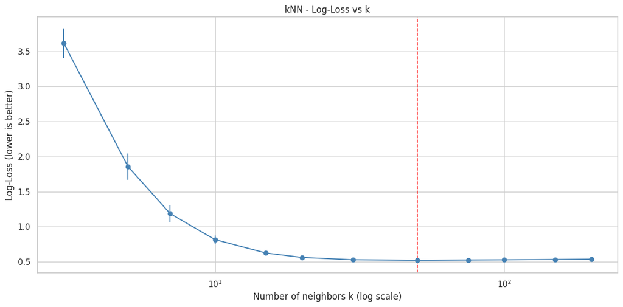

```python
fig, ax = plt.subplots(figsize=(12, 6))
ax.errorbar(knn_df['k'], knn_df['log_loss_mean'], yerr=knn_df['log_loss_std'], fmt='o-', color='steelblue')
ax.set_xscale('log')
ax.axvline(best_k, ls='--', color='red', lw=1.2, label=f'Best k = {best_k}')
ax.set_xlabel('Number of neighbors k (log scale)')
ax.set_ylabel('Log-Loss (lower is better)')
ax.set_title('kNN - Log-Loss vs k')
plt.tight_layout()
plt.show()
```

As anticipated, the optimal K is relatively large. Small k overfits, due to high variance from noisy estimates, while large k underfits. This shows us that the large dimensional space isn't truely local, and the model averages over many points to get stable estimates. This negates the flexibility that makes kNN attractive in lower dimensions.

LDA and QDA

```python
# LDA (no hyperparameters to tune) - just evaluate log-loss
lda_pipe = Pipeline([
    ('pre', preprocessor),
    ('clf', LinearDiscriminantAnalysis())
])
lda_scores = cross_val_score(lda_pipe, x_train, y_train, cv=cv, scoring='neg_log_loss', n_jobs=-1)
lda_log_loss_mean = -lda_scores.mean()
lda_log_loss_std = lda_scores.std()

print(f"LDA - log-loss: {lda_log_loss_mean:.4f} ± {lda_log_loss_std:.4f}")

# QDA (with reg_param tuning)
reg_params = [0.0, 0.1, 0.25, 0.5, 0.75, 0.9, 1.0]
qda_results = []

for reg in reg_params:
    pipe = Pipeline([
        ('pre', preprocessor),
        ('clf', QuadraticDiscriminantAnalysis(reg_param=reg))
    ])
    scores = cross_val_score(pipe, x_train, y_train, cv=cv, scoring='neg_log_loss', n_jobs=-1)
    qda_results.append({
        'reg_param': reg,
        'log_loss_mean': -scores.mean(),
        'log_loss_std': scores.std()
    })
    print(f"QDA (reg_param={reg}) - log-loss: {-scores.mean():.4f} ± {scores.std():.4f}")

qda_df = pd.DataFrame(qda_results)
best_reg = qda_df.loc[qda_df['log_loss_mean'].idxmin(), 'reg_param']
best_ll_qda = qda_df['log_loss_mean'].min()
print(f"\nBest QDA - reg_param={best_reg}, log-loss = {best_ll_qda:.4f}")

if -lda_log_loss_mean < best_ll_qda:
    print("\nLDA performs better than QDA with any regularization.")
else:
    print("\nQDA with regularization performs better than LDA.")
```

```
LDA - log-loss: 0.5872 ± 0.0071
```

[output not shown]

[output cut: 68 more lines]

[output not shown]